# R Notebook - RStudio

[figure not shown]

Tutorial Base per l’utilizzo di RStudio

### **Indice**

- Scaricare/importare dati in RStudio
- Esplorare e trasformare i dati
- Analisi statistica base
- Grafici

## **Scaricare/importare dati in RStudio**

Importeremo 2 dataset:

- *ACS*: American Community Survey. Dataset con informazioni sulla popolazione americana, quali età di marito e moglie, numero di figli, lingua eccetera
- *Titanic*: Alcuni dati relativi ai passeggeri del Titanic: classe, sopravvivenza, sesso, eccetera

### *Da linea di comando*

```r
acs <- read.csv(url("http://stat511.cwick.co.nz/homeworks/acs_or.csv"))
```

Qeusto comando non prodice alcun output, ma possiamo vedere l’oggetto `acs` nel `Global Environment`

### *Dal computer*

Un secondo modo è quello di scaricare il dataset sul computer e poi usare l’*import dataset* di RStudio, nel pannello *“Environment”*.

Questo porta al segente pannello, dove è possibile impostare i parametri di importazione.

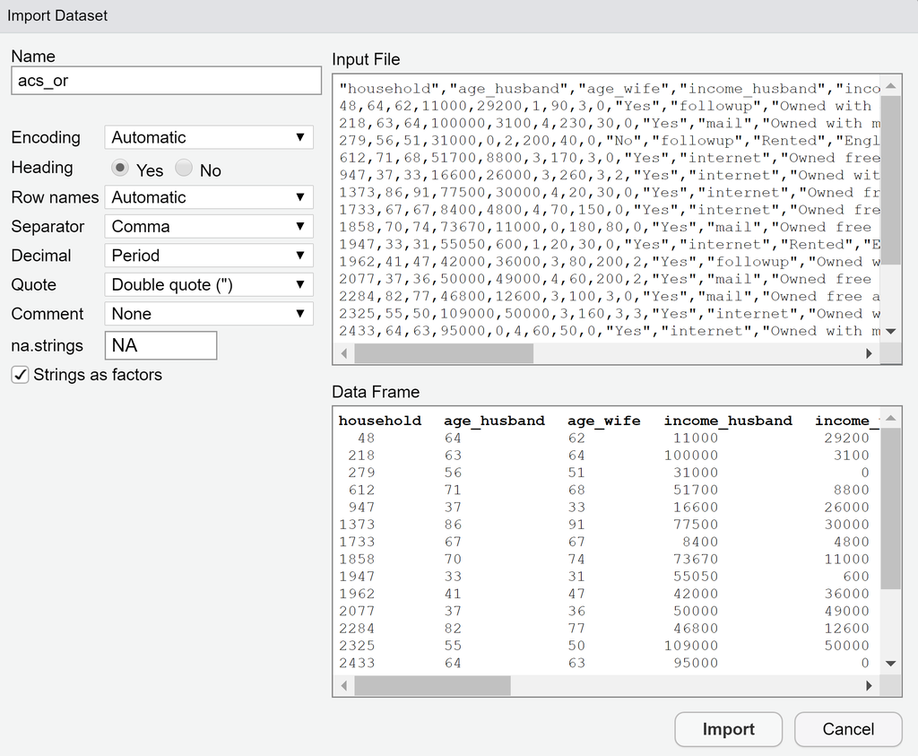

Importiamo anche il dataset Titanic:

```r
titanic <- read.csv("data/titanic.csv")
```

## **Esplorare e trasformare i dati**

Tutti i dataset si possono vedere in RStudio con il comando `View(nome_dataset)`

```r
View(titanic)
```

[figure not shown]

E’ possibile esplorare la struttura del dataset, oppure effettuare trasformazioni:

Struttura del dataset acs:

```r
str(acs)
```

```
'data.frame':   7811 obs. of  14 variables:
 $ household      : int  48 218 279 612 947 1373 1733 1858 1947 1962 ...
 $ age_husband    : int  64 63 56 71 37 86 67 70 33 41 ...
 $ age_wife       : int  62 64 51 68 33 91 67 74 31 47 ...
 $ income_husband : int  11000 100000 31000 51700 16600 77500 8400 73670 55050 42000 ...
 $ income_wife    : int  29200 3100 0 8800 26000 30000 4800 11000 600 36000 ...
 $ bedrooms       : int  1 4 2 3 3 4 4 0 1 3 ...
 $ electricity    : int  90 230 200 170 260 20 70 180 20 80 ...
 $ gas            : int  3 30 40 3 3 30 150 80 30 200 ...
 $ number_children: int  0 0 0 0 2 0 0 0 0 2 ...
 $ internet       : Factor w/ 2 levels "No","Yes": 2 2 1 2 2 2 2 2 2 2 ...
 $ mode           : Factor w/ 3 levels "followup","internet",..: 1 3 1 2 2 2 2 3 2 1 ...
 $ own            : Factor w/ 4 levels "Occupied without payment of rent",..: 3 3 4 2 3 2 2 2 4 3 ...
 $ language       : Factor w/ 3 levels "English only",..: 1 1 1 1 1 1 2 1 1 1 ...
 $ decade_built   : int  1940 1990 1950 1950 1990 1980 1980 2000 1930 2000 ...
```

Struttura del dataset titanic:

```r
str(titanic)
```

```
'data.frame':   887 obs. of  8 variables:
 $ Survived               : int  0 1 1 1 0 0 0 0 1 1 ...
 $ Pclass                 : int  3 1 3 1 3 3 1 3 3 2 ...
 $ Name                   : Factor w/ 887 levels "Capt. Edward Gifford Crosby",..: 602 823 172 814 733 464 700 33 842 839 ...
 $ Sex                    : Factor w/ 2 levels "female","male": 2 1 1 1 2 2 2 2 1 1 ...
 $ Age                    : num  22 38 26 35 35 27 54 2 27 14 ...
 $ Siblings.Spouses.Aboard: int  1 1 0 1 0 0 0 3 0 1 ...
 $ Parents.Children.Aboard: int  0 0 0 0 0 0 0 1 2 0 ...
 $ Fare                   : num  7.25 71.28 7.92 53.1 8.05 ...
```

```r
summary(titanic)
```

```
    Survived          Pclass
 Min.   :0.0000   Min.   :1.000
 1st Qu.:0.0000   1st Qu.:2.000
 Median :0.0000   Median :3.000
 Mean   :0.3856   Mean   :2.306
 3rd Qu.:1.0000   3rd Qu.:3.000
 Max.   :1.0000   Max.   :3.000

                                 Name         Sex
 Capt. Edward Gifford Crosby       :  1   female:314
 Col. John Weir                    :  1   male  :573
 Col. Oberst Alfons Simonius-Blumer:  1
 Don. Manuel E Uruchurtu           :  1
 Dr. Alfred Pain                   :  1
 Dr. Alice (Farnham) Leader        :  1
 (Other)                           :881
      Age        Siblings.Spouses.Aboard Parents.Children.Aboard
 Min.   : 0.42   Min.   :0.0000          Min.   :0.0000
 1st Qu.:20.25   1st Qu.:0.0000          1st Qu.:0.0000
 Median :28.00   Median :0.0000          Median :0.0000
 Mean   :29.47   Mean   :0.5254          Mean   :0.3833
 3rd Qu.:38.00   3rd Qu.:1.0000          3rd Qu.:0.0000
 Max.   :80.00   Max.   :8.0000          Max.   :6.0000

      Fare
 Min.   :  0.000
 1st Qu.:  7.925
 Median : 14.454
 Mean   : 32.305
 3rd Qu.: 31.137
 Max.   :512.329
```

Tabella di frequenza relativa alla classe dei passeggeri del titanic:

```r
table(titanic$Pclass)
```

```
  1   2   3
216 184 487
```

Tabella di frequenza relativa alle lingue parlate dai rispondenti all’acs:

```r
table(acs$language)
```

```
English only        Other      Spanish
        6751          572          488
```

## *Analisi statistica base*

Media

```r
mean(acs$age_husband)
```

```
[1] 54.31776
```

Mediana

```r
median(acs$age_husband)
```

```
[1] 55
```

Quartili

```r
quantile(acs$age_wife)
```

```
  0%  25%  50%  75% 100%
  19   40   53   63   95
```

Varianza

```r
var(acs$age_wife)
```

```
[1] 220.527
```

Deviazione Standard

```r
sd(acs$age_wife)
```

```
[1] 14.85015
```

## Grafici

scatterplot

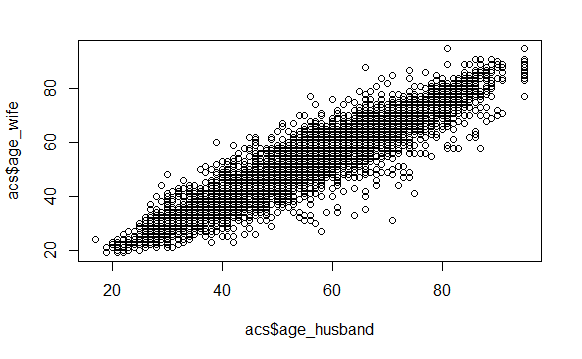

```r
plot(x = acs$age_husband , y = acs$age_wife, type = 'p')
```

Istogramma

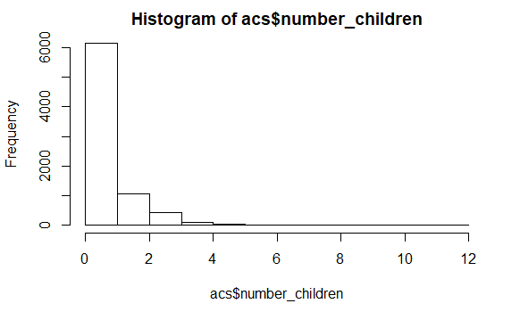

```r
  hist(acs$number_children)
```

Barplot

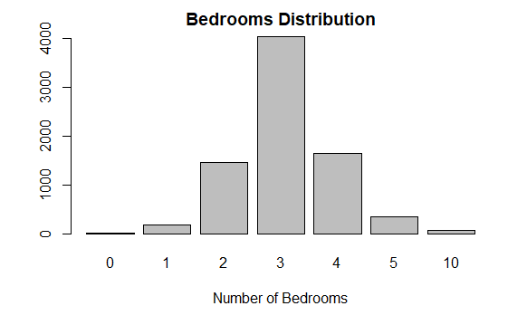

```r
counts <- table(acs$bedrooms)
  barplot(counts, main="Bedrooms Distribution",  xlab="Number of Bedrooms")
```

[figure not shown]